# Applied Multivariate: Identifying differences between groups, part 2

```r
library(vegan)
library(gridExtra)
library(tidyverse)
```

## MANOVA and MANCOVA

Two common multivariate regression models are the multivariate analysis of variance (MANOVA; an extension of the univariate ANOVA) when all predictor variables are categorical, and the multivariate analysis of covariance (MANCOVA; extension of univariate ANCOVA) when predictor variables are categorical and continuous.

### Load the data

```r
bryc_data2 <- read.table("http://ecology.msu.montana.edu/labdsv/R/labs/lab1/bryceveg.R")
bryc_data2 %>% rownames_to_column("site") -> bryc_data
bryc_site_data_og <- read.table("http://ecology.msu.montana.edu/labdsv/R/labs/lab2/brycesite.R")
bryc_site_data_og %>%
  rownames_to_column("site") %>%
  full_join(bryc_data, by = "site") -> bryc_site_data
head(bryc_site_data)
```

|  | site | plotcode | annrad | asp | av | depth | east | elev | grorad | north | pos | quad | slope | junost | ameuta | arcpat | arttri | atrcan | berfre | ceamar | cerled | cermon | chrdep | chrnau | chrpar | chrvis | eurlan | juncom | pacmyr | … |
| --- | --- | --- | --- | --- | --- | --- | --- | --- | --- | --- | --- | --- | --- | --- | --- | --- | --- | --- | --- | --- | --- | --- | --- | --- | --- | --- | --- | --- | --- | --- |
| 1 | bcnp__1 | 50001 | 241 | 30 | 1.00 | deep | 388220.9 | 8720 | 162 | 4144784 | ridge | pc | 9 | 0 | 0.0 | 1.0 | 0 | 0 | 0 | 0.5 | 0 | 0 | 0 | 0 | 0 | 0 | 0 | 0.0 | 0.0 | … |
| 2 | bcnp__2 | 50002 | 222 | 50 | 0.96 | shallow | 388477.2 | 8360 | 156 | 4147573 | mid_slope | pc | 2 | 0 | 0.5 | 0.5 | 0 | 0 | 0 | 0.0 | 0 | 0 | 0 | 0 | 0 | 0 | 0 | 2.0 | 0.5 | … |
| 3 | bcnp__3 | 50003 | 231 | 50 | 0.96 | shallow | 388384.0 | 8560 | 159 | 4147347 | mid_slope | pc | 2 | 0 | 0.0 | 1.0 | 0 | 0 | 0 | 0.5 | 0 | 0 | 0 | 0 | 0 | 0 | 0 | 1.0 | 0.5 | … |
| 4 | bcnp__4 | 50004 | 254 | 360 | 0.93 | shallow | 388307.5 | 8660 | 166 | 4146971 | ridge | pc | 0 | 0 | 0.5 | 1.0 | 0 | 0 | 0 | 0.5 | 0 | 0 | 0 | 0 | 0 | 0 | 0 | 0.0 | 0.0 | … |
| 5 | bcnp__5 | 50005 | 232 | 300 | 0.48 | shallow | 389026.3 | 8480 | 159 | 4146846 | up_slope | pc | 2 | 0 | 0.0 | 4.0 | 0 | 0 | 0 | 0.5 | 0 | 0 | 0 | 0 | 0 | 0 | 0 | 1.0 | 0.5 | … |
| 6 | bcnp__6 | 50006 | 216 | 330 | 0.76 | shallow | 389297.6 | 8560 | 155 | 4146853 | mid_slope | pc | 2 | 0 | 0.5 | 1.0 | 0 | 0 | 0 | 1.0 | 0 | 0 | 0 | 0 | 0 | 0 | 0 | 0.5 | 0.5 | … |

### MANOVA

-Independent variable is a categorical variable - Interpret like ANOVA - degfault test statistic is “Pillai” but “Wilks”, “Hotelling-Lawley”, “Roy” are also available. See `?summary.manova`. Wilks’ statistic is most popular in the literature, but the default Pillai–Bartlett statistic is recommended by [Hand and Taylor (1987)](https://www.crcpress.com/Multivariate-Analysis-of-Variance-and-Repeated-Measures-A-Practical-Approach/Hand-Taylor/p/book/9780412258008)

As a **reminder**:

-R provides Type I sequential SS, not the default Type III marginal SS reported by SAS and SPSS. In a nonorthogonal design with more than one term on the right hand side of the equation order will matter (i.e., A+B and B+A will produce different results)! - Type I sequential SS: tests the main effect of factor A, followed by the main effect of factor B after the main effect of A, followed by the interaction effect AB after the main effects. - Type II: tests for each main effect after the other main effect. No significant interaction is assumed (in other words, you should test for interaction first (SS(AB | A, B)) and only if AB is not significant, continue with the analysis for main effects). - Type III: tests for the presence of a main effect after the other main effect and interaction. This approach is therefore valid in the presence of significant interactions. If the interactions are not significant, type II gives a more powerful test.

- NOTE: when data is balanced, the factors are orthogonal, and types I, II and III all give the same results.
- If you wish to find ways to produce Type II or III SS then you will need to find a package to help. For example, `regr0` has a `drop1()` function for `mlm` models. Install via `install.packages("regr0", repos="http://R-Forge.R-project.org")`

```r
man_out <- manova(cbind(junost,ameuta,arcpat,arttri,atrcan) ~ pos,data = bryc_site_data)
summary(man_out)
```

```
           Df  Pillai approx F num Df den Df  Pr(>F)
pos         4 0.18304    1.477     20    616 0.08253 .
Residuals 155
---
Signif. codes:  0 ‘***’ 0.001 ‘**’ 0.01 ‘*’ 0.05 ‘.’ 0.1 ‘ ’ 1
```

### MANCOVA

- When you have a categorical and continuous independent variables

```r
man_out <- manova(cbind(arcpat, artarb, carrss, purtri,sticom) ~ pos + elev, data = bryc_site_data)
summary(man_out)
```

```
           Df Pillai approx F num Df den Df    Pr(>F)
pos         4 0.2700   2.2150     20    612 0.0018133 **
elev        1 0.1438   5.0387      5    150 0.0002688 ***
Residuals 154
---
Signif. codes:  0 ‘***’ 0.001 ‘**’ 0.01 ‘*’ 0.05 ‘.’ 0.1 ‘ ’ 1
```

## ANOSIM

Analysis of similarities (ANOSIM) provides a way to test statistically whether there is a significant difference between two or more groups of sampling units.

The R-statistic in ANOSIM is a ratio between within-group and between-group dissimilarities. R is interpreted like a correlation coefficient and is a measure of ‘effect size’

R value is supposed to vary between 0 and 1 (not between -1 and +1) but you can obtained negative values but they are always close to 0. R value close to 1 indicates high separation between levels of your factor (e.g. control vs treatment samples), while R value close to 0 indicate no separation between levels of your factor.

```r
# create the y variable
y<-cbind(bryc_site_data$arcpat,bryc_site_data$artarb,bryc_site_data$carrss,bryc_site_data$purtri,bryc_site_data$sticom)
# convert to an x variable
x <- as.factor(bryc_site_data$pos)
# analysis
anosim_out <- anosim(y, x, distance = "euclidean", permutations = 999)
summary(anosim_out)
```

```
Call:
anosim(dat = y, grouping = x, permutations = 999, distance = "euclidean")
Dissimilarity: euclidean

ANOSIM statistic R: 0.0162
      Significance: 0.209

Permutation: free
Number of permutations: 999

Upper quantiles of permutations (null model):
   90%    95%  97.5%    99%
0.0281 0.0388 0.0508 0.0619

Dissimilarity ranks between and within classes:
           0%     25%     50%       75%    100%    N
Between   198 2978.50 6359.50  9536.000 12720.0 9823
bottom    198 4155.00 6932.50  9591.125 12485.0  190
low_slope 198 4070.00 6876.75 10634.500 12716.5  528
mid_slope 198 3220.75 7323.50 10180.000 12704.0 1431
ridge     198 2978.50 6196.50  8470.000 11827.5  153
up_slope  198 1628.50 3863.50  6932.500 11978.0  595
```

The Dissimilarity ranks between and within classes are the ranks of over all dissimilarities for quantiles of the dissimilarities in each “class”. The Between row is for dissimilarities for pairs of samples in different groups. Other rows are the within group pairs.

ANOSIM assumes Between and within (the other rows) should have similar distributions under the Null hypothesis. The table is presented so the user can evaluate whether the assumptions are being met.

P-value is calculated as the probability of an R larger through Monte carlo permutations.

```r
perms<-permustats(anosim_out) # collect the permutation values
perm_data<- data.frame(perm_value = perms$permutations) # convert to a dataframe
perm_data$greater <- ifelse(perm_data$perm_value>=perms$statistic ,1,0)
sum(perm_data$greater)/length(perm_data$greater) # calculate p value
```

```
[1] 0.2082082
```

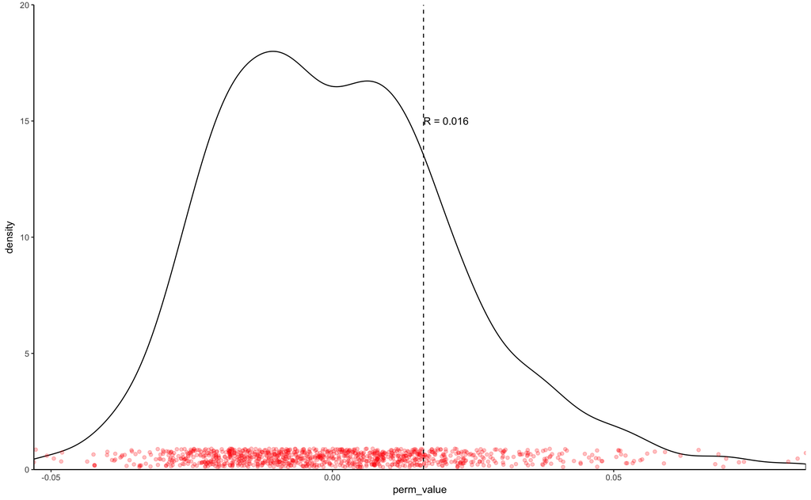

```r
# Illustrate with a plot
ggplot(data = perm_data) +
  geom_density(aes(x = perm_value)) +
  geom_point(aes(x = perm_value, y = 0.5 ), position = "jitter", alpha = 0.25, color = "red") +
  geom_vline(aes(xintercept = perms$statistic ), linetype = "dashed") +
  annotate("text", x = perms$statistic, y = 15, label = paste("R =", round(perms$statistic, digits = 3)), hjust = 0) +
  coord_cartesian(ylim = c(0,20), expand = F) +
  theme_classic()
```

```r
?mrpp
```

## Multiresponse permutation procedure (MRPP)

MRPP provides a test of whether there is a significant difference between two or more groups of sampling units. Difference may be one of location (differences in mean) or one of spread (differences in within-group distance).

MRPP provides little more than a test statistic of effect size and p value.

*A* is proportion of the distances explained by group identity; a value analogous to a coefficient of determination in a linear model. - A = 1 when all items are identical within groups - A = 0 when within-group heterogeneity equals expectation by chance - A < 0.1 common in ecology - A > 0.3 is fairly high in ecology

```r
mrpp_out <- mrpp(y, x, distance = "euclidean", permutations = 999)
mrpp_out
```

```
Call:
mrpp(dat = y, grouping = x, permutations = 999, distance = "euclidean")

Dissimilarity index: euclidean
Weights for groups:  n

Class means and counts:

      bottom low_slope mid_slope ridge up_slope
delta 2.707  2.811     2.735     2.339 1.807
n     20     33        54        18    35

Chance corrected within-group agreement A: 0.02441
Based on observed delta 2.5 and expected delta 2.562

Significance of delta: 0.014
Permutation: free
Number of permutations: 999
```

```r
mrpp_out$A  # measure of effect size
```

```
[1] 0.0244111
```

```r
mrpp_out$Pvalue # p value
```

```
[1] 0.014
```

## Permutational Multivariate Analysis of Variance Using Distance Matrices (Adonis)

Analysis of variance using distance matrices — for partitioning distance matrices among sources of variation and fitting linear models (e.g., factors, polynomial regression) to distance matrices; uses a permutation test with pseudo-F ratios.

`adonis` and `adonis2` are robust methodologies

`adonis` performs a sequential test of terms. `adonis2` performs sequential, marginal and overall tests.

```r
data(dune)
data(dune.env)
adon1_out<-adonis(dune ~ Management*A1, data = dune.env)
adon1_out
```

```
Call:
adonis(formula = dune ~ Management * A1, data = dune.env)

Permutation: free
Number of permutations: 999

Terms added sequentially (first to last)

              Df SumsOfSqs MeanSqs F.Model      R2 Pr(>F)
Management     3    1.4686 0.48953  3.2629 0.34161  0.003 **
A1             1    0.4409 0.44089  2.9387 0.10256  0.018 *
Management:A1  3    0.5892 0.19639  1.3090 0.13705  0.186
Residuals     12    1.8004 0.15003         0.41878
Total         19    4.2990                 1.00000
---
Signif. codes:  0 ‘***’ 0.001 ‘**’ 0.01 ‘*’ 0.05 ‘.’ 0.1 ‘ ’ 1
```

```r
adon2_out <-adonis2(dune ~ Management*A1, data = dune.env, by = "terms", perm=999) # significance for each term (sequentially from first to last),
adon2_out
```

```
Permutation test for adonis under reduced model
Terms added sequentially (first to last)
Permutation: free
Number of permutations: 999

adonis2(formula = dune ~ Management * A1, data = dune.env, permutations = 999, by = "terms")
              Df SumOfSqs      F Pr(>F)
Management     3  1.46859 3.2629  0.002 **
A1             1  0.44089 2.9387  0.026 *
Management:A1  3  0.58918 1.3090  0.216
Residual      12  1.80036
---
Signif. codes:  0 ‘***’ 0.001 ‘**’ 0.01 ‘*’ 0.05 ‘.’ 0.1 ‘ ’ 1
```

```r
adon3_out <-adonis2(dune ~ Management*A1, data = dune.env, by = "margin", perm=999) #  marginal effects of the terms (each marginal term analysed in a model with all other variables)
adon3_out
```

```
Permutation test for adonis under reduced model
Marginal effects of terms
Permutation: free
Number of permutations: 999

adonis2(formula = dune ~ Management * A1, data = dune.env, permutations = 999, by = "margin")
              Df SumOfSqs     F Pr(>F)
Management:A1  3  0.58918 1.309  0.217
Residual      12  1.80036
```

```r
adon4_out <-adonis2(dune ~ Management*A1, data = dune.env, by = NULL, perm=999) #   overall significance of all terms together.
adon4_out
```

```
Permutation test for adonis under reduced model
Permutation: free
Number of permutations: 999

adonis2(formula = dune ~ Management * A1, data = dune.env, permutations = 999, by = NULL)
         Df SumOfSqs      F Pr(>F)
Model     7   2.4987 2.3792  0.001 ***
Residual 12   1.8004
---
Signif. codes:  0 ‘***’ 0.001 ‘**’ 0.01 ‘*’ 0.05 ‘.’ 0.1 ‘ ’ 1
```

```r
stargazer(mod)
```

[output not shown]